# General

- Introduction: https://gpflow.readthedocs.io/en/develop/intro.html

```python
import gpflow
import numpy as np
import matplotlib
%matplotlib inline
matplotlib.rcParams['figure.figsize'] = (12, 6)
plt = matplotlib.pyplot
```

GP regression (with Gaussian noise) is the most straightforward GP model in GPflow. Because of the conjugacy of the latent process and the noise, the marginal likelihood p(y|θ) can be computed exactly.

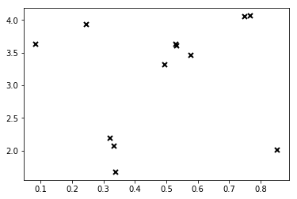

```python
# Build data sets
N = 12
X = np.random.rand(N,1)
Y = np.sin(12*X) + 0.66*np.cos(25*X) + np.random.randn(N,1)*0.1 + 3
plt.plot(X, Y, 'kx', mew=2)
```

## Construct model

Instanciate GPFlow model class, in this case GPR. To do so one has to define a kernel (k). Variance is set by initial guess

```python
k = gpflow.kernels.Matern52(1, lengthscales=0.3)
m = gpflow.models.GPR(X, Y, kern=k)
m.likelihood.variance = 0.01
```

```
WARNING:gpflow.logdensities:Shape of x must be 2D at computation.
```

## Prediction

GPflow models have several prediction methods:

- m.predict_f returns the mean and variance of the latent function (f) at the points Xnew.
- m.predict_f_full_cov additionally returns the full covariance matrix of the prediction.
- m.predict_y returns the mean and variance of a new data point (i.e. includes the noise varaince). In the case of non-Gaussian likelihoods, the variance is computed by (numerically) integrating the non-Gaussian likelihood.
- m.predict_f_samples returns samples of the latent function
- m.predict_density returns the log-density of the points Ynew at Xnew.

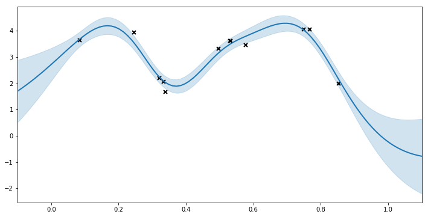

```python
def plot(m):
    xx = np.linspace(-0.1, 1.1, 100).reshape(100, 1)
    mean, var = m.predict_y(xx)
    plt.figure(figsize=(12, 6))
    plt.plot(X, Y, 'kx', mew=2)
    plt.plot(xx, mean, 'C0', lw=2)
    plt.fill_between(xx[:,0],
                     mean[:,0] - 2*np.sqrt(var[:,0]),
                     mean[:,0] + 2*np.sqrt(var[:,0]),
                     color='C0', alpha=0.2)
    plt.xlim(-0.1, 1.1)

plot(m)
```

## Using mean functions

All GPflow models can have parameterized mean functions, some simple ones are provided in gpflow.mean_functions. Here’s a model with a Linear mean function.

```python
k = gpflow.kernels.Matern52(1, lengthscales=0.3)
meanf = gpflow.mean_functions.Linear(1.0, 0.0)
m = gpflow.models.GPR(X, Y, k, meanf)
m.likelihood.variance = 0.01
```

```
WARNING:gpflow.logdensities:Shape of x must be 2D at computation.
```

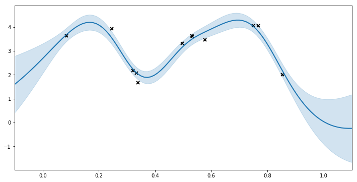

```python
plot(m)
```

## Maximum Likelihood estimation of θ

Getting the ML estimate of the parameters is a simple call to minimize method of the optimizer’s instance, for e.g. gpflow.train.ScipyOptimizer(). By default, GPflow plugs into the L-BFGS-B algorithm via scipy. Here are the parameters before optimization:

```python
m.as_pandas_table()
```

|  | class | prior | transform | trainable | shape | fixed_shape | value |
| --- | --- | --- | --- | --- | --- | --- | --- |
| GPR/kern/lengthscales | Parameter | None | +ve | True | () | True | 0.3 |
| GPR/kern/variance | Parameter | None | +ve | True | () | True | 1.0 |
| GPR/likelihood/variance | Parameter | None | +ve | True | () | True | 0.01 |
| GPR/mean_function/A | Parameter | None | (none) | True | (1, 1) | True | [[1.0]] |
| GPR/mean_function/b | Parameter | None | (none) | True | () | True | 0.0 |

Parameters after optimization and a new plot (still same data).

```
INFO:tensorflow:Optimization terminated with:
  Message: b'CONVERGENCE: REL_REDUCTION_OF_F_<=_FACTR*EPSMCH'
  Objective function value: 9.115953
  Number of iterations: 21
  Number of functions evaluations: 24
```

[output not shown]

|  | class | prior | transform | trainable | shape | fixed_shape | value |
| --- | --- | --- | --- | --- | --- | --- | --- |
| GPR/kern/lengthscales | Parameter | None | +ve | True | () | True | 0.06344822059760553 |
| GPR/kern/variance | Parameter | None | +ve | True | () | True | 0.7048635869479293 |
| GPR/likelihood/variance | Parameter | None | +ve | True | () | True | 0.017298219882998664 |
| GPR/mean_function/A | Parameter | None | (none) | True | (1, 1) | True | [[-1.0078298254875462]] |
| GPR/mean_function/b | Parameter | None | (none) | True | () | True | 3.624268038162578 |

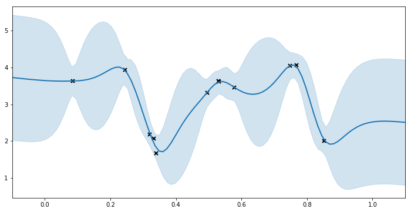

```python
gpflow.train.ScipyOptimizer().minimize(m)
plot(m)
m.as_pandas_table()
```

Note that the local optimum found by Maximum Likelihood may not be the one you want, e.g. it may be overfitting or be oversmooth. This depends on the initial values of hyperparameters and is specific to each data set. This discussion is beyond the scope of GPflow; an introduction can be found, for example, at A Practical Guide to Gaussian Processes (https://drafts.distill.pub/gp/).

## MCMC for θ

Here’s a quick demonstration of how to obtain posteriors over the hyper-parameters in GP regression. First, we’ll set some priors on the kernel parameters, then we’ll run MCMC and see how much posterior uncertainty there is in the parameters.

First we’ll choose rather arbitrary priors.

```python
m.clear()
m.kern.lengthscales.prior = gpflow.priors.Gamma(1., 1.)
m.kern.variance.prior = gpflow.priors.Gamma(1., 1.)
m.likelihood.variance.prior = gpflow.priors.Gamma(1., 1.)
#meanf = gpflow.mean_functions.Linear(1.0, 0.0)

# print(m)
# print(str(type(m)))

# print(m.mean_function)
# print(str(type(m.mean_function)))

# print(m.mean_function.A)
# print(str(type(m.mean_function.A)))
m.mean_function.A.prior = gpflow.priors.Gaussian(0., 10.)
m.mean_function.b.prior = gpflow.priors.Gaussian(0., 10.)
m.compile()
m.as_pandas_table()
```

```
WARNING:gpflow.logdensities:Shape of x must be 2D at computation.
```

|  | class | prior | transform | trainable | shape | fixed_shape | value |
| --- | --- | --- | --- | --- | --- | --- | --- |
| GPR/kern/lengthscales | Parameter | Ga(1.0,1.0) | +ve | True | () | True | 0.3 |
| GPR/kern/variance | Parameter | Ga(1.0,1.0) | +ve | True | () | True | 1.0 |
| GPR/likelihood/variance | Parameter | Ga(1.0,1.0) | +ve | True | () | True | 1.0 |
| GPR/mean_function/A | Parameter | N(0.0,10.0) | (none) | True | (1, 1) | True | [[1.0]] |
| GPR/mean_function/b | Parameter | N(0.0,10.0) | (none) | True | () | True | 0.0 |

```python
# HMC = Hamiltonian Monte Carlo: https://gpflow.readthedocs.io/en/latest/notebooks/mcmc.html
sampler = gpflow.train.HMC()
samples = sampler.sample(m, num_samples=gpflow.test_util.notebook_niter(500), epsilon=0.05, lmin=10, lmax=20, logprobs=False)
```

```
WARNING:gpflow.logdensities:Shape of x must be 2D at computation.
WARNING:gpflow.logdensities:Shape of x must be 2D at computation.
WARNING:gpflow.logdensities:Shape of x must be 2D at computation.
```

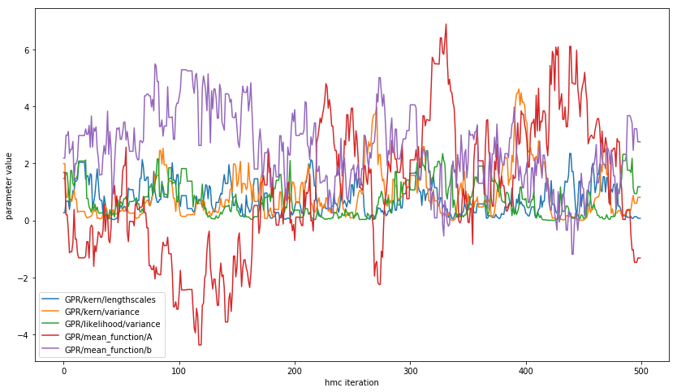

```python
plt.figure(figsize=(14,8))
for i, col in samples.iteritems():
    plt.plot(col, label=col.name)
plt.legend(loc=0)
plt.xlabel('hmc iteration')
plt.ylabel('parameter value')
```

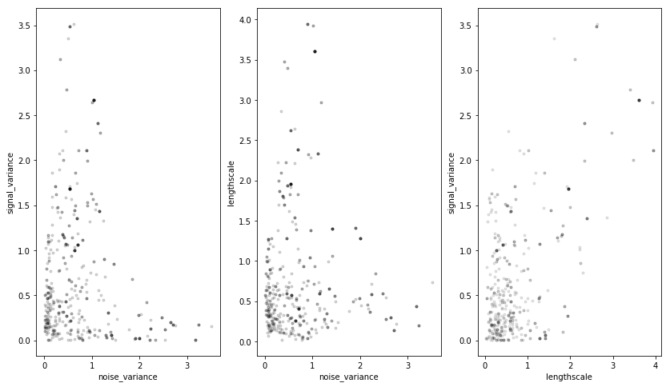

```python
f, axs = plt.subplots(1,3, figsize=(14,8))

axs[0].plot(samples['GPR/likelihood/variance'],
            samples['GPR/kern/variance'], 'k.', alpha = 0.15)
axs[0].set_xlabel('noise_variance')
axs[0].set_ylabel('signal_variance')

axs[1].plot(samples['GPR/likelihood/variance'],
            samples['GPR/kern/lengthscales'], 'k.', alpha = 0.15)
axs[1].set_xlabel('noise_variance')
axs[1].set_ylabel('lengthscale')

axs[2].plot(samples['GPR/kern/lengthscales'],
            samples['GPR/kern/variance'], 'k.', alpha = 0.1)
axs[2].set_xlabel('lengthscale')
axs[2].set_ylabel('signal_variance')
```

To plot the posterior of predictions, we’ll iterate through the samples and set the model state with each sample. Then, for that state (set of hyper-parameters) we’ll draw some samples from the prediction function.

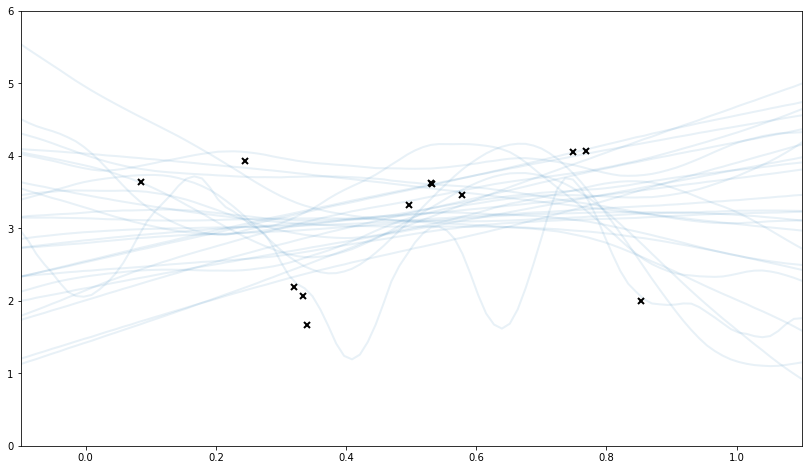

```python
#plot the function posterior
xx = np.linspace(-0.1, 1.1, 100)[:,None]
plt.figure(figsize=(14,8))
for i, s in samples.iloc[::20].iterrows():
    f = m.predict_f_samples(xx, 1, initialize=False, feed_dict=m.sample_feed_dict(s))
    plt.plot(xx, f[0,:,:], 'C0', lw=2, alpha=0.1)

plt.plot(X, Y, 'kx', mew=2)
_ = plt.xlim(xx.min(), xx.max())
_ = plt.ylim(0, 6)
```

Note the bimodal posterior: the data can be explained by a very smooth function (with lots of noise) or as a rough, short lengthscale function.